# Predicción del rating de Las aplicaciones en Google Play Store

Reto DataSource

[Edimer (Sidereus)](https://edimer.github.io/)

[figure not shown]

- [Sitio oficial del reto en DataSource.](https://www.datasource.ai/es/home/data-science-competitions-for-startups/prediciendo-el-rating-de-las-aplicaciones-en-google-play-store)

# Metodología

- Las siguientes imágenes fueron tomadas del libro [Tidy Modeling with R](https://xgboost.readthedocs.io/en/latest/parameter.html) de [Max Kuhn](https://github.com/topepo) y [Julia Silge.](https://github.com/juliasilge)

## Marco General

[figure not shown]

## Estrategia de Validación

- La siguiente imagen fue tomada de [tidymodels.org](https://www.tidymodels.org/start/case-study/) e ilustra la estrategia de evaluación de modelos que adopté.

[figure not shown]

## Fases del Modelado

[figure not shown]

## Libros

### *Tidy Modeling with R*

- Consultar libro [aquí](https://www.tmwr.org/)

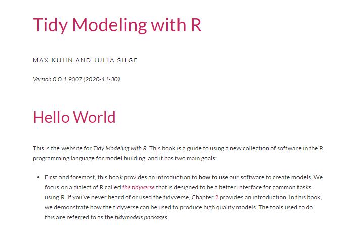

### *Applied Predictive Modeling*

- Consultar el libro [aquí.](http://appliedpredictivemodeling.com/)

[figure not shown]

### *Feature Engineering and Selection A Practical Approach for Predictive Models*

- Consultar libro [aquí.](http://www.feat.engineering/)

[figure not shown]

# Variables

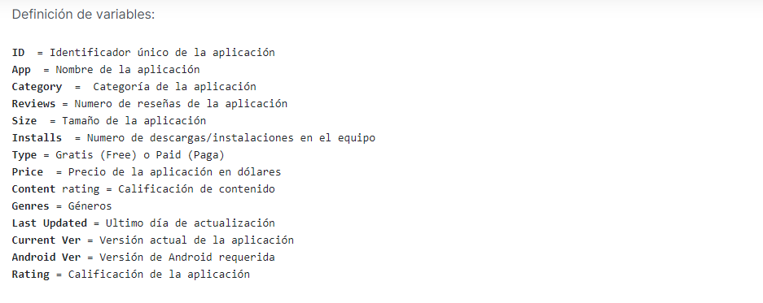

# Datos

```r
# Cargando datos
library(tidyverse)
load("../data/my_train1.Rdata")
load("../data/my_test1.Rdata")
sampleSub <- read_csv("../data/sample_submission.csv")
head(new_train1)
```

| App | Category | Rating | Reviews | Type | content_rating | new_genres | date_update | new_day | new_year | size_kb | new_installs | new_price | new_month_num | new_version | new_subversion | min_android |
| --- | --- | --- | --- | --- | --- | --- | --- | --- | --- | --- | --- | --- | --- | --- | --- | --- |
| GPS Status & Toolbox | Travel_and_local | 1 | 149723 | Free | Everyone | Travel & Local | 2018-06-13 | 13 | 2018 | 4100 | 1e+07 | 0.00 | 6 | 8 | 1 | 4.0 |
| Fish\|Hunt FL | Lifestyle | 0 | 853 | Free | Everyone | Lifestyle | 2018-03-22 | 22 | 2018 | 34000 | 1e+05 | 0.00 | 3 | 3 | 2 | 4.1 |
| Allrecipes Dinner Spinner | Food_and_drink | 1 | 61881 | Free | Everyone | Food & Drink | 2018-04-10 | 10 | 2018 | NA | 5e+06 | 0.00 | 4 | NA | NA | NA |
| Don't touch my phone | Tools | 0 | 21943 | Free | Everyone | Tools | 2016-10-19 | 19 | 2016 | 2300 | 5e+06 | 0.00 | 10 | NA | NA | 2.3 |
| BM SPM Practice | Family | 1 | 6 | Free | Everyone | Education | 2018-01-24 | 24 | 2018 | 9200 | 1e+03 | 0.00 | 1 | 1 | 0 | 4.1 |
| Advanced EX for FIAT | Tools | 0 | 138 | Paid | Everyone | Tools | 2015-03-05 | 5 | 2015 | 141 | 5e+03 | 4.99 | 3 | 1 | 6 | 1.6 |

- Selecciono sólo las variables que van a ingresar al análisis.

```r
mi_train <- new_train1 %>%
  select(-c(App, date_update))

mi_test <- new_test1 %>%
  select(-c(App, date_update))
```

- Primero se garantiza que los modelos sean entrenados con las mismas variables que contiene el archivo de test (submission).

```r
library(fastDummies)
# Binarización en test
binar_train <- dummy_cols(mi_train, remove_selected_columns = TRUE)
binar_test <- dummy_cols(mi_test, remove_selected_columns = TRUE)

# Las mismas variables en train y test (submission)
variables_iguales <- c(names(binar_train)[names(binar_train) %in% names(binar_test)],
                       "Rating")

# Datos de train finales
binar_train <- binar_train[, variables_iguales]
```

# Modelos

- [Redes Neuronales (*Perceptrón Multicapa - MLP*)](https://parsnip.tidymodels.org/reference/mlp.html)
- Preprocesamiento:
  - Binarización (previamente binarizadas).
  - Imputación a través de *knn*.
  - Transformación Yeo-Johnson
  - Escalado y normalización.
  - Como es un problema de clasificación imbalanceado, utilizo la biblioteca themis para generar clases balanceadas a través de muestreo con reemplazo (ascendnete - *upsample*).
- Pasos a seguir con *tidymodels*:
  - 0. División en *train*, *validación* y *test*
  - 1. Definir preprocesamiento
  - 2. Definir el modelo y los hiperparámetros a optimizar
  - 3. Definir la estrategia de validación del modelo
  - 4. Definir tipo de *tuning* (grid de hiperparámetros)
  - 5. Definir el frujo de trabajo (*workflow* en *tidymodels*)
  - 6. Ejecución o entrenamiento de modelos (*tuning*)
  - 7. Evaluación de modelos (gráficos con métricas de error)
  - 8. Ajuste del modelo final
  - 9. Predicciones finales

# Etapas del modelo

## Etapa 0 - Split

```r
# Preprocesamiento
library(themis)
library(tidymodels)

# Train-Test
set.seed(2020)
data_split <- initial_split(data = binar_train, prop = 0.80)
data_train <- training(data_split) %>% mutate(Rating = as.factor(Rating))
data_test <- testing(data_split) %>% mutate(Rating = as.factor(Rating))
```

## Etapa 1 - Preprocesamiento

```r
receta1 <- recipe(Rating ~ ., data = data_train) %>%
  step_knnimpute(all_predictors(), neighbors = 2) %>%
  step_YeoJohnson(all_numeric(), -all_outcomes()) %>%
  step_normalize(all_numeric(), -all_outcomes()) %>%
  step_upsample(Rating)
```

## Etapa 2 - Modelos

- [Ejemplo de clasificación a través de *Perceptrón Multicapa* con *keras*](https://www.tidymodels.org/learn/models/parsnip-nnet/)

```r
# Modelo Red Neuronal (MLP)
library(keras)
mod_mlp <- mlp(
  mode = "classification",
  hidden_units = tune(),
  dropout = tune(),
  epochs = 100,
  activation = tune()
) %>%
  set_engine("keras")
```

## Etapa 3 - Validación

```r
set.seed(1234)
cv_config <- vfold_cv(data = data_train,
                      v = 5,
                      strata = Rating)
```

## Etapa 4 - Grid Tuning

- En este caso voy a usar máxima entropia de tamaño 20. El proceso de capacitación o entrenamiento es bastante lento.

```r
# Hiperparámetros Modelo Red Neuronal (MLP)
set.seed(12345)
mlp_params <- parameters(
  hidden_units(range = c(1, 20)),
  dropout(),
  activation()
)

mlp_grid <- grid_max_entropy(mlp_params,
                             size = 20)
```

## Etapa 5 - *Workflow*

```r
# Workflow Modelo Red Neuronal (MLP)
mlp_wflow <- workflow() %>%
  add_recipe(receta1) %>%
  add_model(mod_mlp)
```

## Etapa 6 - *Tuning*

- **Tuning Red Neuronal:** tiempo de ejecución aproximado de 2 horas.

```r
# Tiempos
library(tictoc)
tic() # Tiempo 0

#doParallel::registerDoParallel(parallel::detectCores() - 1) # Inicio Paralelización

# Tuning
mlp_tuned <- tune_grid(
  object = mlp_wflow,
  resamples = cv_config,
  grid = mlp_grid,
  metrics = metric_set(roc_auc, f_meas),
  control = control_grid(save_pred = TRUE)
)

#doParallel::stopImplicitCluster() # Fin Paralelización

toc() # Tiempo final
```

## Etapa 7 - Evaluación de modelos

- En este caso los mejores modelos con ambas métricas resultaron en el mismo.

### Hiperparámetros ROC-AUC

- **Tabla resumen:**

```r
mlp_tuned %>%
  collect_metrics() %>%
  filter(.metric == "roc_auc") %>%
  arrange(desc(mean))
```

| hidden_units | dropout | activation | .metric | .estimator | mean | n | std_err | .config |
| --- | --- | --- | --- | --- | --- | --- | --- | --- |
| 4 | 0.8959378558 | elu | roc_auc | binary | 0.7320377 | 5 | 0.004495671 | Preprocessor1_Model14 |
| 9 | 0.7739854231 | elu | roc_auc | binary | 0.7200808 | 5 | 0.007115814 | Preprocessor1_Model19 |
| 17 | 0.8289058509 | elu | roc_auc | binary | 0.7140601 | 5 | 0.007191999 | Preprocessor1_Model15 |
| 2 | 0.2486217497 | elu | roc_auc | binary | 0.7041830 | 5 | 0.019634255 | Preprocessor1_Model03 |
| 11 | 0.7854045164 | relu | roc_auc | binary | 0.7037687 | 5 | 0.004428629 | Preprocessor1_Model04 |
| 19 | 0.8996717460 | relu | roc_auc | binary | 0.6984227 | 5 | 0.005619685 | Preprocessor1_Model11 |
| 8 | 0.5175021437 | relu | roc_auc | binary | 0.6947415 | 5 | 0.003672892 | Preprocessor1_Model08 |
| 18 | 0.1022169250 | elu | roc_auc | binary | 0.6932263 | 5 | 0.004239691 | Preprocessor1_Model10 |
| 9 | 0.0709677772 | relu | roc_auc | binary | 0.6881706 | 5 | 0.006821597 | Preprocessor1_Model18 |
| 20 | 0.5011446849 | softmax | roc_auc | binary | 0.6842921 | 5 | 0.006163325 | Preprocessor1_Model20 |

[output cut: 10 more lines]

- **Hiperparámetros:**

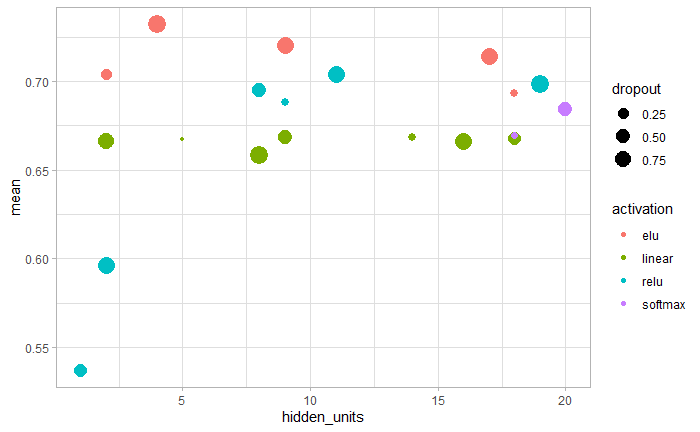

```r
mlp_tuned %>%
  collect_metrics() %>%
  filter(.metric == "roc_auc") %>%
  ggplot(aes(x = hidden_units, y = mean, size = dropout, color = activation)) +
  geom_point() +
  theme_light()
```

### Desemepeño

- **Ajuste con mejores hiperparámetros:**

```r
# Mejores parámetros
mejor_roc <- select_best(mlp_tuned, metric = "roc_auc")

# Finalizando workflow
modelo_final1 <- finalize_workflow(
  x = mlp_wflow,
  parameters = mejor_roc
)

modelo_final1_fit <- modelo_final1 %>%
  fit(data = data_train)
```

- **Predicciones en Train:**

```r
# Clases predichas en train
clases_train <- modelo_final1_fit %>%
  predict(new_data = data_train, type = "class")

# Probabilidades predichas en train
probs_train <- modelo_final1_fit %>%
  predict(new_data = data_train, type = "prob")

# Reales, clases predichas y probabilidades predichas
predichos_train <- bind_cols(clases_train, probs_train) %>%
  mutate(real = data_train$Rating)

head(predichos_train)
```

| .pred_class | .pred_0 | .pred_1 | real |
| --- | --- | --- | --- |
| 1 | 0.4239691 | 0.5760309 | 1 |
| 0 | 0.6386484 | 0.3613517 | 0 |
| 1 | 0.4619095 | 0.5380906 | 1 |
| 0 | 0.6321845 | 0.3678155 | 0 |
| 1 | 0.4178749 | 0.5821251 | 1 |
| 0 | 0.5792453 | 0.4207547 | 0 |

- **Matriz de confusión en Train:**

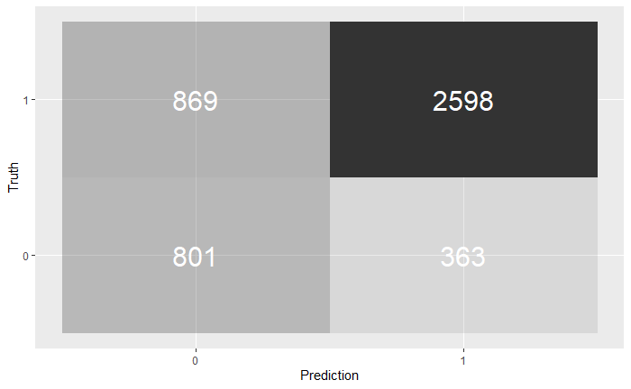

```r
predichos_train %>%
  conf_mat(real, .pred_class) %>%
  pluck(1) %>%
  as_tibble() %>%
  ggplot(aes(x = Prediction, y = Truth, alpha = n)) +
  geom_tile(show.legend = FALSE) +
  geom_text(aes(label = n), colour = "white", alpha = 1, size = 8)
```

- **Precisión en Train:**

```r
predichos_train %>%
  accuracy(real, .pred_class)
```

| .metric | .estimator | .estimate |
| --- | --- | --- |
| accuracy | binary | 0.7339667 |

- **Curva ROC:**

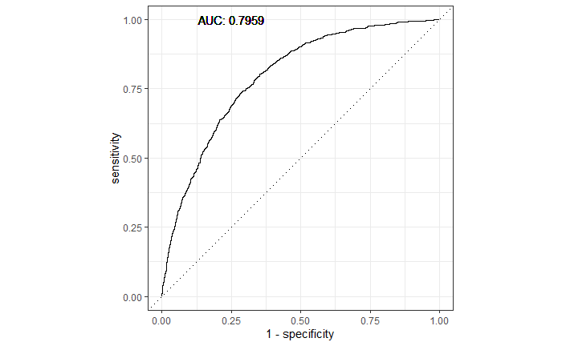

```r
predichos_train %>%
  roc_curve(real, .pred_0) %>%
  autoplot() +
  geom_text(aes(
    x = 0.25,
    y = 1,
    label = paste0(
      "AUC: ",
      predichos_train %>%
        roc_auc(real, .pred_0) %>%
        pull(.estimate) %>%
        round(digits = 4)
    )
  ))
```

- **Predicciones en Validación:**

```r
# Clases predichas en train
clases_val <- modelo_final1_fit %>%
  predict(new_data = data_test, type = "class")

# Probabilidades predichas en train
probs_val <- modelo_final1_fit %>%
  predict(new_data = data_test, type = "prob")

# Reales, clases predichas y probabilidades predichas
predichos_val <- bind_cols(clases_val, probs_val) %>%
  mutate(real = data_test$Rating)

head(predichos_val)
```

| .pred_class | .pred_0 | .pred_1 | real |
| --- | --- | --- | --- |
| 1 | 0.4800299 | 0.5199702 | 1 |
| 0 | 0.5756857 | 0.4243143 | 1 |
| 1 | 0.4204597 | 0.5795403 | 1 |
| 1 | 0.4039246 | 0.5960755 | 1 |
| 0 | 0.5085500 | 0.4914500 | 1 |
| 1 | 0.2553661 | 0.7446339 | 1 |

- **Matriz de confusión en Validación:**

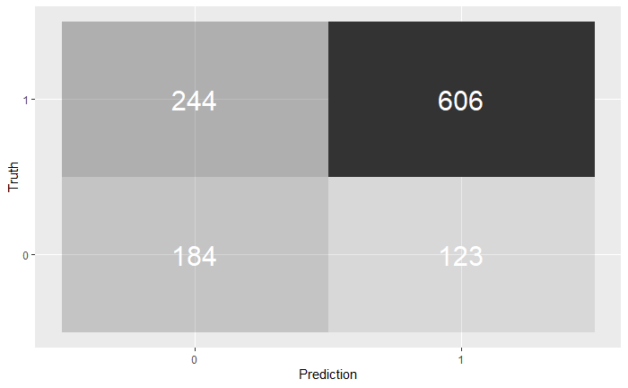

```r
predichos_val%>%
  conf_mat(real, .pred_class) %>%
  pluck(1) %>%
  as_tibble() %>%
  ggplot(aes(x = Prediction, y = Truth, alpha = n)) +
  geom_tile(show.legend = FALSE) +
  geom_text(aes(label = n), colour = "white", alpha = 1, size = 8)
```

```r
predichos_val %>%
  accuracy(real, .pred_class)
```

| .metric | .estimator | .estimate |
| --- | --- | --- |
| accuracy | binary | 0.6828003 |

- **Curva ROC:**

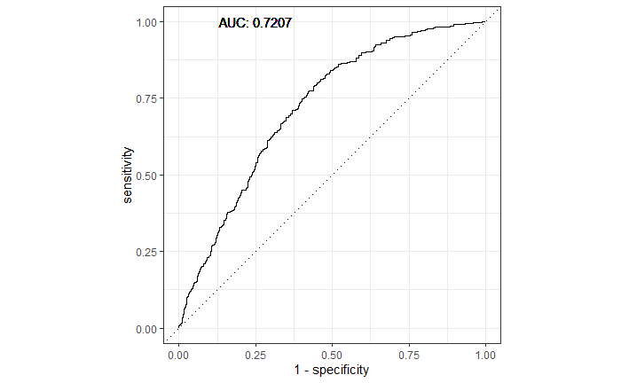

```r
predichos_val %>%
  roc_curve(real, .pred_0) %>%
  autoplot() +
  geom_text(aes(
    x = 0.25,
    y = 1,
    label = paste0(
      "AUC: ",
      predichos_val %>%
        roc_auc(real, .pred_0) %>%
        pull(.estimate) %>%
        round(digits = 4)
    )
  ))
```

### Hiperparámetros F1 Score

- **Tabla resumen:**

```r
mlp_tuned %>%
  collect_metrics() %>%
  filter(.metric == "f_meas") %>%
  arrange(desc(mean))
```

| hidden_units | dropout | activation | .metric | .estimator | mean | n | std_err | .config |
| --- | --- | --- | --- | --- | --- | --- | --- | --- |
| 4 | 0.8959378558 | elu | f_meas | binary | 0.5161264 | 5 | 0.006739931 | Preprocessor1_Model14 |
| 9 | 0.7739854231 | elu | f_meas | binary | 0.4934468 | 5 | 0.011934164 | Preprocessor1_Model19 |
| 17 | 0.8289058509 | elu | f_meas | binary | 0.4925986 | 5 | 0.009471136 | Preprocessor1_Model15 |
| 2 | 0.2486217497 | elu | f_meas | binary | 0.4835019 | 5 | 0.018319582 | Preprocessor1_Model03 |
| 11 | 0.7854045164 | relu | f_meas | binary | 0.4806836 | 5 | 0.004279164 | Preprocessor1_Model04 |
| 19 | 0.8996717460 | relu | f_meas | binary | 0.4782796 | 5 | 0.003972297 | Preprocessor1_Model11 |
| 18 | 0.1022169250 | elu | f_meas | binary | 0.4667160 | 5 | 0.007244817 | Preprocessor1_Model10 |
| 8 | 0.5175021437 | relu | f_meas | binary | 0.4644426 | 5 | 0.013945328 | Preprocessor1_Model08 |
| 9 | 0.0709677772 | relu | f_meas | binary | 0.4643578 | 5 | 0.013018503 | Preprocessor1_Model18 |
| 2 | 0.6825063052 | linear | f_meas | binary | 0.4601266 | 5 | 0.007894804 | Preprocessor1_Model13 |

[output cut: 10 more lines]

- **Hiperparámetros:**

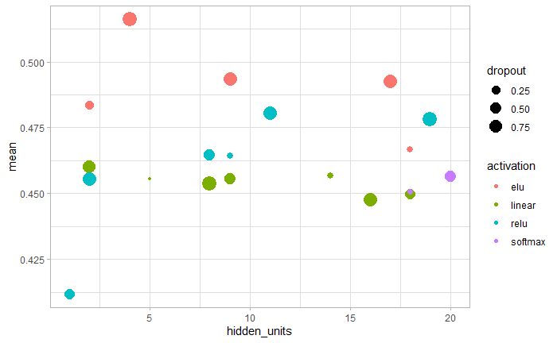

```r
mlp_tuned %>%
  collect_metrics() %>%
  filter(.metric == "f_meas") %>%
  ggplot(aes(x = hidden_units, y = mean, size = dropout, color = activation)) +
  geom_point() +
  theme_light()
```

# Modelo Final

```r
# Finalizando modelación
prep_final <- prep(x = receta1)
data_final <- bake(object = prep_final,
                   new_data = binar_train %>% mutate(Rating = as.factor(Rating)))

modelo_completo <- modelo_final1 %>%
  fit(data = data_final)
```

# Submission

- **Predicciones finales:**

```r
# Receta sobre datos de test
test_final <- bake(object = prep_final, new_data = binar_test)

# Predicciones sobre test (submission)
predichos_final <- modelo_completo %>%
  predict(new_data = test_final, type = "class")

# Submission
sampleSub %>%
  select(-rating) %>%
  mutate(rating = predichos_final$.pred_class) ->
  sub_41_mlp
head(sub_41_mlp)
```

| id | rating |
| --- | --- |
| 5788 | 1 |
| 5789 | 1 |
| 5790 | 1 |
| 5791 | 1 |
| 5792 | 0 |
| 5793 | 0 |

- **Exportando predicciones:**

```r
write_csv(sub_41_mlp, file = "../submission/sub_41_mlp.csv")
```

# Probabilidades

- Este modelo tuvo buen rendimiento en el tablero de la competencia. Voy a analizar cómo es la distribución de las probabilidades predichas.
- Hasta ahora sólo obtuve predicciones directas (*hard*), es decir, la clase o etiqueta final. Asumiendo el límite de probabilidad por defecto, que es 0.5.
- La calibración de modelos podría suministrar mejores resultados. Con ello se podría obtener algún criterio estadístico para definir el punto de corte (*threshold*).

```r
# Predicciones sobre test (submission)
predichos_final2 <- modelo_completo %>%
  predict(new_data = test_final, type = "prob")
```

- **Distribución de probabilides predichas:**

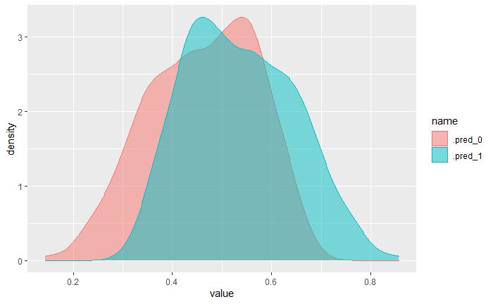

```r
predichos_final2 %>%
  pivot_longer(cols = everything()) %>%
  ggplot(aes(x = value, fill = name, color = name)) +
  geom_density(alpha = 0.5)
```

- **Cambiando punto de corte a 0.55:**

```r
predichos_final2 %>%
  mutate(rating = if_else(.pred_1 > 0.55, true = "1", false = "0")) ->
  predichos_probs

# Submission
sampleSub %>%
  select(-rating) %>%
  mutate(rating = predichos_probs$rating) ->
  sub_42_mlp
head(sub_42_mlp)
```

| id | rating |
| --- | --- |
| 5788 | 1 |
| 5789 | 1 |
| 5790 | 1 |
| 5791 | 1 |
| 5792 | 0 |
| 5793 | 0 |

- **Exportando predicciones:**

```r
write_csv(sub_42_mlp, file = "../submission/sub_42_mlp.csv")
```

- **Cambiando punto de corte a 0.45:**

```r
predichos_final2 %>%
  mutate(rating = if_else(.pred_1 > 0.45, true = "1", false = "0")) ->
  predichos_probs2

# Submission
sampleSub %>%
  select(-rating) %>%
  mutate(rating = predichos_probs2$rating) ->
  sub_43_mlp
head(sub_43_mlp)
```

| id | rating |
| --- | --- |
| 5788 | 1 |
| 5789 | 1 |
| 5790 | 1 |
| 5791 | 1 |
| 5792 | 0 |
| 5793 | 0 |

- **Exportando predicciones:**

```r
write_csv(sub_43_mlp, file = "../submission/sub_43_mlp.csv")
```

- **Cambiando punto de corte a 0.40:**

```r
predichos_final2 %>%
  mutate(rating = if_else(.pred_1 > 0.40, true = "1", false = "0")) ->
  predichos_probs3

# Submission
sampleSub %>%
  select(-rating) %>%
  mutate(rating = predichos_probs3$rating) ->
  sub_44_mlp
head(sub_44_mlp)
```

| id | rating |
| --- | --- |
| 5788 | 1 |
| 5789 | 1 |
| 5790 | 1 |
| 5791 | 1 |
| 5792 | 1 |
| 5793 | 1 |

- **Exportando predicciones:**

```r
write_csv(sub_44_mlp, file = "../submission/sub_44_mlp.csv")
```

- **Cambiando punto de corte a 0.47:**

```r
predichos_final2 %>%
  mutate(rating = if_else(.pred_1 > 0.47, true = "1", false = "0")) ->
  predichos_probs4

# Submission
sampleSub %>%
  select(-rating) %>%
  mutate(rating = predichos_probs4$rating) ->
  sub_45_mlp
head(sub_45_mlp)
```

| id | rating |
| --- | --- |
| 5788 | 1 |
| 5789 | 1 |
| 5790 | 1 |
| 5791 | 1 |
| 5792 | 0 |
| 5793 | 0 |

- **Exportando predicciones:**

```r
write_csv(sub_45_mlp, file = "../submission/sub_45_mlp.csv")
```

# Exportando probabilidades

```r
write_csv(predichos_final2, file = "../probabilitys/prob_mlp.csv")
```